# Sentiment analysis of Epic Games Store through Resetera posts

Edward Velo Fuentes

2/27/2022

[figure not shown]

[figure not shown]

Source: Wikimedia Commons

# Background

In this article we try to measure the public opinion towards the Epic Games Store using posts scrapped from the Resetera forums. We’ll analyze a dataset that we obtained using web scrapping techniques from the rvest package at www.resetera.com, and then go through the common data science pipeline (importing, cleaning and exploring) in order to check if the general opinion towards the known digital game store has somewhat improved.

# Introduction

After four years of improvements and the expanding of their game catalogue, the question that we want to answer is: Has the public opinion on the EGS gone better or worse as of 2022? In order to answer the proposed question, we’ll be using sentiment analysis with posts obtained through web scrapping from the Resetera forums, one of the most popular videogame forums on the internet. As a user of the forums myself, I know that the opinion about the EGS on the forum wasn’t quite good around its launch period, to say the least, so I’m really interested if it’s been shifted in this regard towards one way or the other. The sentiment analysis will be employed using the sentiment lexicon from (Nielsen, 2011), which numerically scores different words from -5 (most negative) to 5 (most positive). Gauging the general opinion from any thread would consist of summing all the scores from the identified words and checking if the total sum is above or below zero, evaluating the general sentiment as positive or negative, respectively. Sentiment analysis using the AFINN lexicon is by no means to be exhaustive (that is, we are not making any judgement in basis of modelling or statistical inference), but can shed some light in the general perception of any kind of subject.

# Preparing data and packages

```r
## Installing necessary packages
install.packages(c("pracma", "polite", "tidytext",
                   "wordcloud", "rebus", "textdata",
                   "stopwords"))
```

```
## Installing pracma [2.3.8] ...
##  OK [linked cache]
## Installing polite [0.1.1] ...
##  OK [linked cache]
## Installing tidytext [0.3.2] ...
##  OK [linked cache]
## Installing wordcloud [2.6] ...
##  OK [linked cache]
## Installing rebus [0.1-3] ...
##  OK [linked cache]
## Installing textdata [0.4.1] ...
##  OK [linked cache]
## Installing stopwords [2.3] ...
##  OK [linked cache]
```

```r
## Importing packages
library(tidyverse)
library(tidytext)
library(wordcloud)
library(rvest)
library(reshape2)
library(polite)
library(stringr)
library(rebus)
library(lubridate)
library(xts)
library(infer)
library(parallel)
library(parallelly)
library(pracma)
library(knitr)
library(kableExtra)

## Loading our own functions
source(file.path("input", "ReseteraFunctions.R"), encoding = "utf-8")

## Importing the datasets
rst_thread_df_raw <- read_csv(file.path("data", "rst_thread_df_raw.csv"))
sentiments <- read_csv(file.path("data", "afinn.csv"))

## Setting the plot theme
rst_palette <- c("#7847B5", "#8952CD", "#FEF9FE", "#9F75DB", "#8B70B4")

theme_set(
  theme(panel.background = element_rect(fill = rst_palette[3]),
        panel.grid.major.x = element_line(colour = rst_palette[5]),
        panel.grid.major.y = element_blank())
)
```

# Web scrapping using rvest

Our objective through the use of web scrapping is to have a data frame where we store different posts and other features related it. We are going to use the *rvest* package by Hadley Wickham, which is an useful package for this purpose and includes nice tidy syntax in its functions. The code in this section won’t be evaluated because of time constraints (importing all the pertinent info lasts around 24 minutes), but will be shown here regardless. The actual dataset has been saved already in csv format and will be imported like usual through a readr package function.

First of all, we’ll identify all Resetera threads that are about the Epic Games Store. The method for this will be using the google search engine with the following query: *resetera epic games store site:www.resetera.com*

```r
## Connecting to Google ====

# We intend to extract resetera urls through Google, at least for 10 different
# search pages

## Base url
ggle_rst_base <- "https://www.google.com/search?q=resetera+epic+games+store+site:www.resetera.com&"
```

Because google usually returns not one, but multiple pages with possible results, we decide to make a list of different versions of the main url contained in the variable *ggle_rst_base* to check for every possible page:

```r
## Then, we create a list for 10 search pages adding a pattern to ggle_rst_base
ggle_rst_urls <- paste0(ggle_rst_base, "start=", seq(0, 90, by = 10), "&")

head(ggle_rst_urls)

# Let's save google xmls in a list
ggle_cookies_list <- map(ggle_rst_urls, read_html)

head(ggle_cookies_list, 2)
```

If we need to accept cookies (which we don’t here on the DataCamp workspace, but I had to anyway when working on my desktop), we have to use the following code, in order to query the actual search results. We plan for this using the *html_form_submit()* function, which by default chooses an “Accept” button anywhere on the webpage. Then, we read the htmls of the google pages:

```r
# We need to get past cookies
ggle_xml_list <- ggle_cookies_list %>%
  map(html_form) %>%
  map(1) %>%
  map(html_form_submit, submit = "button") %>%
  map(read_html)
```

After getting past cookies, we read the url’s from the actual threads of the Resetera forums. Some user defined functions are used here, like *extract_google_url()* or *ultima_pag()*: The former is used to clean unwanted characters from google urls on the HTML page, while the latter is intended to avoid using while loops during the post extraction in the forum threads, by identifying the last page from every thread (This last chunk of code won’t be evaluated because of time constraints).

```r
# Retrieve text that includes URLs, then extract those URLs
# with a specific function
rst_thread_urls <- ggle_cookies_list %>%
  map(function(x)
  {
    html_elements(x, "a") %>%
      as.character() %>%
      # Extract only urls
      extract_google_url() %>%
      # Filter out URLs that are not related to Resetera
      str_subset("^((?!google.com).)*$")
  }
  ) %>%
  # We unlist this for clarity
  unlist()

# Some thread urls found by Google results don't begin in the first page of that
# thread. Therefore, we need to rewrite some of the urls
rst_thread_urls <- rst_thread_urls %>%
  str_remove("page-\\d+")

head(rst_thread_urls)

# In order to construct adequate loops for reach thread, we need to
# know the last page for every thread
rst_thread_last <- rst_thread_urls %>%
  map(bow) %>%
  map(scrape) %>%
  map(ultima_pag) %>%
  map(as.numeric)

# If there's only one page, fill those spaces with a number one
rst_thread_last[map_lgl(rst_thread_last, function(x) length(x) == 0)] <- 1
```

As we did before, we now create versions of the URL from every imported Resetera thread but for every page inside those same threads. We use a for loop here in the form of the *map2()* function:

```r
# We'll create a list with every page for every thread
rst_thread_urls_full <- rst_thread_urls %>%
  map2(rst_thread_last, function(x, y) paste0(x, "page-", 1:y)) %>%
  unlist()
```

Extracting text messages will be a computationally expensive task, so we are using parallel processing for it. We use the *parallel* package for this. Also, we include the *polite* package, which makes the web scraping process more clean by telling the web host who we are:

```r
# Create cluster with 3 CPU nodes
clusterino <- makeClusterPSOCK(3)

# We export the user defined functions an libraries to the cluster
clusterExport(clusterino, c('extract_rst_text', 'rm_quotes', 'ultima_pag', 'extract_google_url'))

clusterEvalQ(clusterino, library(tidyverse))
clusterEvalQ(clusterino, library(tidytext))
clusterEvalQ(clusterino, library(rvest))
clusterEvalQ(clusterino, library(lubridate))
clusterEvalQ(clusterino, library(polite))
```

One thing of interest when we scrap posts is how we identify the actual text from the posts. By inspecting the HTML code from the webpage, we see that posts are located under a class called “.BBWrapper”, as illustrated in the following image:

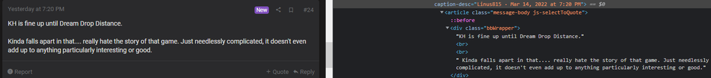

*Left: A caption from one of the forum’s posts. Right: HTML code from that post.*

Then, we proceed with the extraction inside the cluster:

```r
# Begin the extraction of every post from every identified thread
tic()

rst_thread_extracts <- parLapplyLB(clusterino, rst_thread_urls_full, fun = function(x)

  {
    extract_rst_text(scrape(bow(x)))
  }

)

elapsed_cluster_time <- toc()

# Disconnect the cluster
stopCluster(clusterino)
```

Having every post imported inside a list, we proceed to combine it into a data frame, and then write the object into a csv format for future work:

```r
# Merge all the elements from the list into one dataframe
rst_thread_df_raw <- bind_rows(rst_thread_extracts)

# Write the dataset into a csv file for future imports
write_csv(rst_thread_df_raw, "data/rst_thread_df_raw.csv")
```

## Exploring and cleaning

The sample dataset, contained in the variable *rst_thread_df_raw*, its composed of 33206 rows and 4 columns. The main purpose of this sample is to track different posts from the forums that come from a thread related to the EGS, which are contained in the variable *Post*. Because our study is focused around time, we also have date information, contained in the variable *Date*, which ranges between 2018-12-06 (the store’s launch date) and 2022-03-02`, and spans from minutes to years. Lastly, we also have *Thread_title* and *Page*, the former being important from tracking most positive/negative threads, and the latter only being useful for tracking purposes (to remove unwanted characters, dots, etc…).

```r
head(rst_thread_df_raw)
```

```
## # A tibble: 6 × 4
##   Thread_title                 Page Date                Post
##   <chr>                       <dbl> <dttm>              <chr>
## 1 Epic Games Store Discussion     1 2018-12-12 17:55:00 "I’ve noticed a ton of …
## 2 Epic Games Store Discussion     1 2018-12-12 18:01:00 "Automated refunds are …
## 3 Epic Games Store Discussion     1 2018-12-12 18:03:00 "I think it's less the …
## 4 Epic Games Store Discussion     1 2018-12-12 18:06:00 "Exactly. That's why al…
## 5 Epic Games Store Discussion     1 2018-12-12 18:08:00 "Their refunds policy i…
## 6 Epic Games Store Discussion     1 2018-12-12 18:08:00 "Reposting what I think…
```

```r
summary(rst_thread_df_raw)
```

```
##  Thread_title            Page            Date
##  Length:33206       Min.   : 1.00   Min.   :2018-12-06 21:39:00
##  Class :character   1st Qu.: 3.00   1st Qu.:2019-03-20 13:38:00
##  Mode  :character   Median : 9.00   Median :2019-08-01 13:51:00
##                     Mean   :15.38   Mean   :2020-01-08 15:47:51
##                     3rd Qu.:21.00   3rd Qu.:2021-01-07 15:55:00
##                     Max.   :81.00   Max.   :2022-03-02 07:34:00
##                     NA's   :675
##      Post
##  Length:33206
##  Class :character
##  Mode  :character
##
##
##
##
```

We first deal with the creation of *Year* and *Month*, and converting *Page* into an integer variable. Note that we translate the changes into a new variable called *rst_thread_df*:

```r
rst_thread_df <- rst_thread_df_raw %>%
  mutate(Year = year(Date),
         Month = month(Date),
         Page = as.integer(Page)
         )
```

We’ll be also removing threads that doesn’t have Epic Games as its main subject:

```r
# Number of threads before removing those not related to Epic
rst_thread_df %>% distinct(Thread_title) %>% nrow()
```

```
## [1] 98
```

```r
# Removing threads that don't have anything to do with Epic Games
rst_thread_df <- rst_thread_df %>%
  filter(str_detect(Thread_title, "Epic"))

# Number of threads after removing those unrelated to Epic
rst_thread_df %>% distinct(Thread_title) %>% nrow()
```

```
## [1] 90
```

Missing posts probably appear because of promotional posts that only include advertising an no text. We’ll filter them out:

```r
rst_thread_df <- rst_thread_df %>%
  # Use a regular expression to identify empty posts
  filter(!str_detect(Post, "^$"))
```

Duplicated rows can be a problem because the total score calculation could be biased. There are a total of 616 duplicated rows, which translated in our context means duplicated posts. We remove them with the following code, using a regular expression:

```r
## The total of duplicated rows
sum(duplicated.data.frame(rst_thread_df))
```

```
## [1] 616
```

```r
rst_thread_df %>%
## Frequencies of threads and pages, in descending order
  count(Thread_title, Page, Date, Post) %>%
  arrange(desc(n)) %>%
  # Just show posts that have been repeated at least twice
  filter(n > 1) %>%
  # Which threads are duplicated?
  distinct(Thread_title)
```

```
## # A tibble: 2 × 1
##   Thread_title
##   <chr>
## 1 "Epic Games Store changes its refund policy to match Steam's, adds local pric…
## 2 "Epic Games Store Exclusive \"Tetris Effect\" Requires SteamVR to run in VR m…
```

```r
## We remove duplicated rows by selecting the first element of a combination of
## four different factors
rst_thread_df <- rst_thread_df %>%
  group_by(Thread_title, Page, Date, Post) %>%
  slice(1) %>%
  ungroup()

## There's no duplicates anymore!
sum(duplicated.data.frame(rst_thread_df))
```

```
## [1] 0
```

When someone embeds an image inside a post on Resetera, an HTML code is used for creating a box around the quote. This translates into our sample with a few posts having words like “lightbox” or “Click to expand”. We’ll be using a pattern to remove all of this code from the dataframe:

```r
# Example of a few posts with the lightbox pattern
rst_thread_df %>%
  filter(str_detect(Post, "lightbox")) %>%
  slice(1) %>%
  pull(Post)
```

```
## [1] "{ \"lightbox_close\": \"Close\", \"lightbox_next\": \"Next\", \"lightbox_previous\": \"Previous\", \"lightbox_error\": \"The requested content cannot be loaded. Please try again later.\", \"lightbox_start_slideshow\": \"Start slideshow\", \"lightbox_stop_slideshow\": \"Stop slideshow\", \"li…
```

```r
## Create pattern to remove those HTML words
lightbox_pattern <- '\\{ \"lightbox_close\".+\"Toggle sidebar\" \\}'
click_pattern <- 'Click to expand... Click to shrink...'

rst_thread_df <- rst_thread_df %>%
  mutate(Post = Post %>%
           str_remove(lightbox_pattern) %>%
           str_remove_all(click_pattern) %>%
           # Trim whitespaces from both sides and inside
           str_squish()) %>%
  ## This leads to new empty posts, so we remove them again
  filter(!str_detect(Post, "^$"))

## The same post as the example but without the pattern
rst_thread_df %>%
  filter(str_detect(Post, "lightbox")) %>%
  slice(1) %>%
  pull(Post)
```

```
## character(0)
```

Threads showing NA in the Page column are single-paged threads. We’ll substitute that with a number one using a single line of code:

```r
rst_thread_df[is.na(rst_thread_df$Page),]$Page <- 1
```

Now we have our dataset cleaned. It looks like the following:

```r
head(rst_thread_df)
```

```
## # A tibble: 6 × 6
##   Thread_title                        Page Date                Post   Year Month
##   <chr>                              <int> <dttm>              <chr> <dbl> <dbl>
## 1 [Gematsu] Salt and Sacrifice for …     1 2021-10-18 09:40:00 The …  2021    10
## 2 [Gematsu] Salt and Sacrifice for …     1 2021-10-18 09:46:00 Ah w…  2021    10
## 3 [Gematsu] Salt and Sacrifice for …     1 2021-10-18 09:47:00 I'm …  2021    10
## 4 [Gematsu] Salt and Sacrifice for …     1 2021-10-18 09:50:00 i am…  2021    10
## 5 [Gematsu] Salt and Sacrifice for …     1 2021-10-18 09:52:00 The …  2021    10
## 6 [Gematsu] Salt and Sacrifice for …     1 2021-10-18 09:52:00 You …  2021    10
```

Now we are ready to use the sentiment lexicon for the analysis.

## Tokenization with tidytext

Using the **tidytext** package we can score different posts according to a sentiment lexicon. First of all, we need to tokenize posts, so we can separate words from a post into its proper column. From that point onwards, we’ll be able to score words according to sentiments. A relevant issue is the fact that certain words can mean an entirely different thing besides some specific words (for example, “good” is a nice sentiment, but “not good” isn’t). In order to adress this, we have to go through multiple steps.

First, we tokenize words in pairs, so we have one row for each succesive pair. For example, a post like “I want to eat breakfast” would be tokenized as “I want” in the first row, “want to”, “to eat”, etc… and so on:

```r
# Tokenize words into pairs
rst_tkn_word_df <- rst_thread_df %>%
  unnest_ngrams(Word, Post, n_min = 2L, n = 2L, drop = FALSE)
head(rst_tkn_word_df %>% select(-Date))
```

```
## # A tibble: 6 × 6
##   Thread_title                                      Page Post   Year Month Word
##   <chr>                                            <int> <chr> <dbl> <dbl> <chr>
## 1 [Gematsu] Salt and Sacrifice for PC is launchin…     1 The …  2021    10 the …
## 2 [Gematsu] Salt and Sacrifice for PC is launchin…     1 The …  2021    10 pc v…
## 3 [Gematsu] Salt and Sacrifice for PC is launchin…     1 The …  2021    10 vers…
## 4 [Gematsu] Salt and Sacrifice for PC is launchin…     1 The …  2021    10 of s…
## 5 [Gematsu] Salt and Sacrifice for PC is launchin…     1 The …  2021    10 salt…
## 6 [Gematsu] Salt and Sacrifice for PC is launchin…     1 The …  2021    10 and …
```

```r
# Separate Word column into Word_1 and Word_2
rst_tkn_word_df <- rst_tkn_word_df %>%
  separate(Word, into = c("pre_Word", "Word"), sep = " ")

rst_tkn_word_df %>% select(contains("Word"))
```

```
## # A tibble: 1,239,415 × 2
##    pre_Word  Word
##    <chr>     <chr>
##  1 the       pc
##  2 pc        version
##  3 version   of
##  4 of        salt
##  5 salt      and
##  6 and       sacrifice
##  7 sacrifice will
##  8 will      be
##  9 be        available
## 10 available exclusively
## # … with 1,239,405 more rows
```

```r
sentiments_df <- sentiments %>%
  # Add "don't like" to the lexicon
  bind_rows(data.frame(word = "don't like", value = -2),
            # Add "exclusivity" and "exclusively" as negative words
            data.frame(word = c("exclusivity", "exclusively"), value = -2)) %>%
  # Change "exclusive" score to a negative one
  mutate(value = case_when(word == "exclusive" ~ -2,
                           TRUE ~ value)) %>%
  # Capitalize variable names
  rename_all(str_to_title)

# Create a vector of negative conjunctions
ngt_words <- c("no", "not", "never", "dont", "don't", "cannot", "can't", "won't",
    "wouldn't", "shouldn't", "aren't", "isn't", "wasn't", "weren't", "haven't",
    "hasn't", "hadn't", "doesn't", "didn't", "mightn't", "mustn't")

# With the AFINN sentiment lexicon, we can classify words by its sentiments
rst_tkn_word_afinn <- rst_tkn_word_df %>%
  # This join will enable a new column, Value, that scores words from Word_2
  inner_join(sentiments_df, by = c("Word" = "Word")) %>%
  # We update values from Value according to negative words in Word_1
  mutate(Value = ifelse(pre_Word %in% ngt_words, -Value, Value)) %>%
  # A general classifier for positives and negatives could be useful
  mutate(Sentiment = ifelse(Value > 0, "positive", "negative"))

head(rst_tkn_word_afinn)
```

```
## # A tibble: 6 × 10
##   Thread_title   Page Date                Post   Year Month pre_Word Word  Value
##   <chr>         <int> <dttm>              <chr> <dbl> <dbl> <chr>    <chr> <dbl>
## 1 [Gematsu] Sa…     1 2021-10-18 09:40:00 The …  2021    10 availab… excl…    -2
## 2 [Gematsu] Sa…     1 2021-10-18 09:40:00 The …  2021    10 and      supp…     2
## 3 [Gematsu] Sa…     1 2021-10-18 09:47:00 I'm …  2021    10 ps5      lol       3
## 4 [Gematsu] Sa…     1 2021-10-18 09:47:00 I'm …  2021    10 looks    exce…     3
## 5 [Gematsu] Sa…     1 2021-10-18 09:47:00 I'm …  2021    10 the      free      1
## 6 [Gematsu] Sa…     1 2021-10-18 09:50:00 i am…  2021    10 i'm      happy     3
## # … with 1 more variable: Sentiment <chr>
```

```r
# Now some words, like "like", are scored negatively if precedeed by a negative
# word
rst_tkn_word_afinn %>% filter(Word == "like")
```

```
## # A tibble: 6,566 × 10
##    Thread_title  Page Date                Post   Year Month pre_Word Word  Value
##    <chr>        <int> <dttm>              <chr> <dbl> <dbl> <chr>    <chr> <dbl>
##  1 [Gematsu] S…     1 2021-10-18 09:52:00 "You…  2021    10 posts    like      2
##  2 [Gematsu] S…     1 2021-10-18 09:59:00 "I'd…  2021    10 it       like      2
##  3 [Gematsu] S…     1 2021-10-18 10:04:00 "Thi…  2021    10 they     like      2
##  4 [Gematsu] S…     1 2021-10-18 10:04:00 "Thi…  2021    10 sometim… like      2
##  5 [Gematsu] S…     1 2021-10-18 10:04:00 "Thi…  2021    10 they     like      2
##  6 [Gematsu] S…     1 2021-10-18 10:04:00 "Thi…  2021    10 i        like      2
##  7 [Gematsu] S…     1 2021-10-18 10:04:00 "Thi…  2021    10 it       like      2
##  8 [Gematsu] S…     1 2021-10-18 10:07:00 "Enj…  2021    10 posts    like      2
##  9 [Gematsu] S…     1 2021-10-18 10:10:00 "I d…  2021    10 don't    like     -2
## 10 [Gematsu] S…     1 2021-10-18 10:11:00 "Or …  2021    10 i        like      2
## # … with 6,556 more rows, and 1 more variable: Sentiment <chr>
```

Now that the tokenization is ready, we can do some EDA on our data.

# Exploratory Data Analysis

We first begin looking at the distribution of the words scored by the sentiment lexicon. Having discrete values, an histogram wouldn’t be useful for this situation, so we choose using a bar diagram:

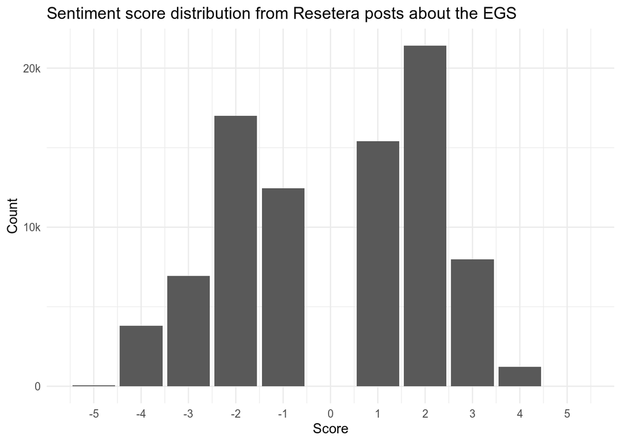

```r
rst_tkn_word_afinn %>%
  ggplot(aes(x = Value)) +
  geom_bar() +
  theme_minimal() +
  labs(title = "Sentiment score distribution from Resetera posts about the EGS",
       x = "Score",
       y = "Count") +
  scale_y_continuous(labels = c("0", "10k", "20k"),
                     breaks = c(0, 10000, 20000)) +
  scale_x_continuous(breaks = -5:5)
```

We can see that the distribution is bimodal: The two most common values are -2 and 2, being the most positive ones more frequent than the negative. Because of the bimodal nature, using measures like the average won’t be that representative.

## Global analysis

Now that we have our sentiment classification ready, we’ll proceed with a visual summary of the scores obtained through the sentiment analysis. Keep in mind that we’ll start with a general exploration, and then break it up by time periods. Which are the most common words *overall*?

```r
# Most common words overall
rst_tkn_word_df %>%
  count(Word) %>%
  arrange(desc(n))
```

```
## # A tibble: 25,666 × 2
##    Word      n
##    <chr> <int>
##  1 the   47412
##  2 to    36707
##  3 a     27216
##  4 and   25252
##  5 of    20946
##  6 that  19944
##  7 is    19613
##  8 i     19313
##  9 it    18006
## 10 for   15417
## # … with 25,656 more rows
```

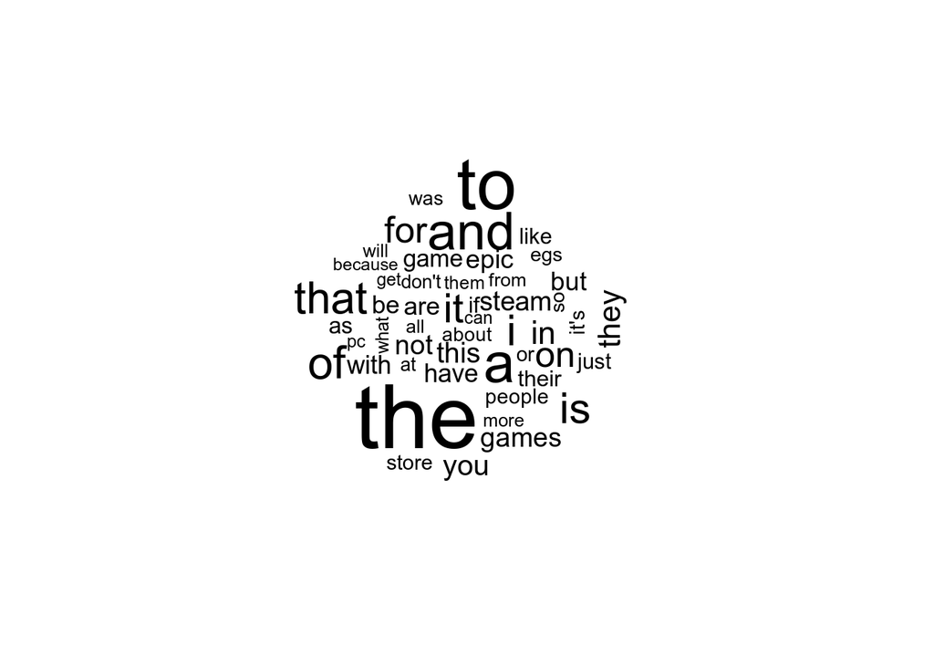

```r
# A wordcloud for most common words
rst_tkn_word_df %>%
  count(Word) %>%
  with(wordcloud(Word, n, max.words = 50))
```

Most common words are articles and conjunctions, which isn’t interesting. In order to filter for more interesting words, we can filter out these types of words using a stopwords lexicon, like as follows:

```r
# We retrieve articles and conjunctions
rst_tkn_word_nostop <- rst_tkn_word_df %>%
  anti_join(get_stopwords(), by = c("Word" = "word"))

rst_tkn_word_nostop %>%
  count(Word) %>%
  arrange(desc(n))
```

```
## # A tibble: 25,493 × 2
##    Word       n
##    <chr>  <int>
##  1 games   9600
##  2 steam   9587
##  3 epic    9088
##  4 game    7924
##  5 like    6566
##  6 just    6440
##  7 store   5961
##  8 people  5833
##  9 egs     5447
## 10 pc      4124
## # … with 25,483 more rows
```

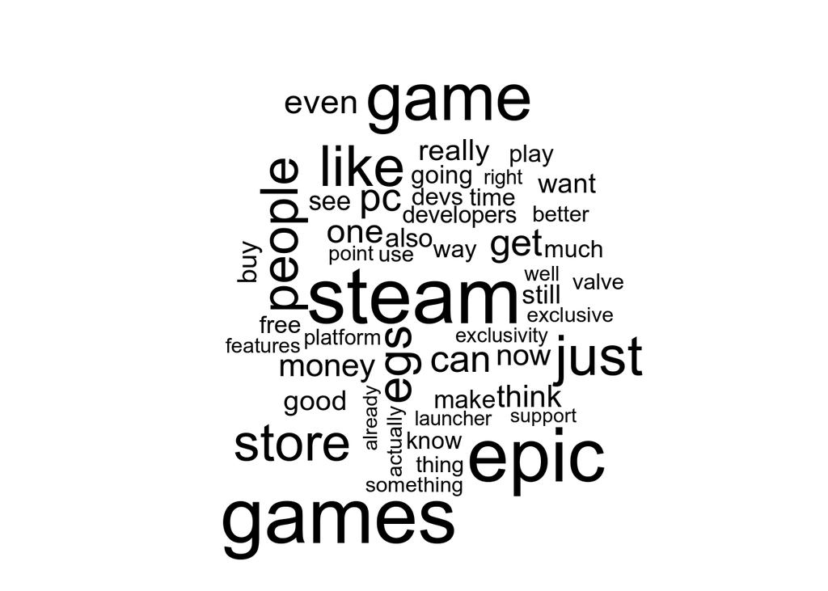

```r
# Most common words, again
rst_tkn_word_nostop %>%
  count(Word) %>%
  with(wordcloud(Word, n, max.words = 50))
```

Not surprisingly, “games” is the most mentioned name, followed by “steam”, being this one a direct competitor to the Epic Games Store. Other interesting words are “exclusivity”, which may refer to exclusive games that are included in the EGS (mainly games from Ubisoft and some indie companies).

How’s the distribution of positive and negative words separately?

```r
# Total percentage of positive and negative words
(summary_pst_ngt <- rst_tkn_word_afinn %>%
  group_by(Sentiment) %>%
  summarize(Count = n(),
            Proportion = scales::percent(Count / nrow(.), 0.01)) %>%
  arrange(desc(Proportion))
)
```

```
## # A tibble: 2 × 3
##   Sentiment Count Proportion
##   <chr>     <int> <chr>
## 1 positive  46036 53.36%
## 2 negative  40241 46.64%
```

```r
# Most common positive words
rst_tkn_word_afinn %>%
  filter(Value > 0) %>%
  count(Word) %>%
  arrange(desc(n))
```

```
## # A tibble: 873 × 2
##    Word        n
##    <chr>   <int>
##  1 like     5991
##  2 good     2494
##  3 free     1985
##  4 want     1970
##  5 better   1728
##  6 big      1232
##  7 support  1198
##  8 pretty    940
##  9 great     738
## 10 lol       674
## # … with 863 more rows
```

```r
# Most common negative words
rst_tkn_word_afinn %>%
  filter(Value < 0) %>%
  count(Word) %>%
  arrange(desc(n))
```

```
## # A tibble: 1,247 × 2
##    Word            n
##    <chr>       <int>
##  1 no           3639
##  2 exclusive    1547
##  3 exclusivity  1462
##  4 cut          1200
##  5 shit         1167
##  6 bad          1154
##  7 fuck          724
##  8 problem       681
##  9 like          575
## 10 pay           555
## # … with 1,237 more rows
```

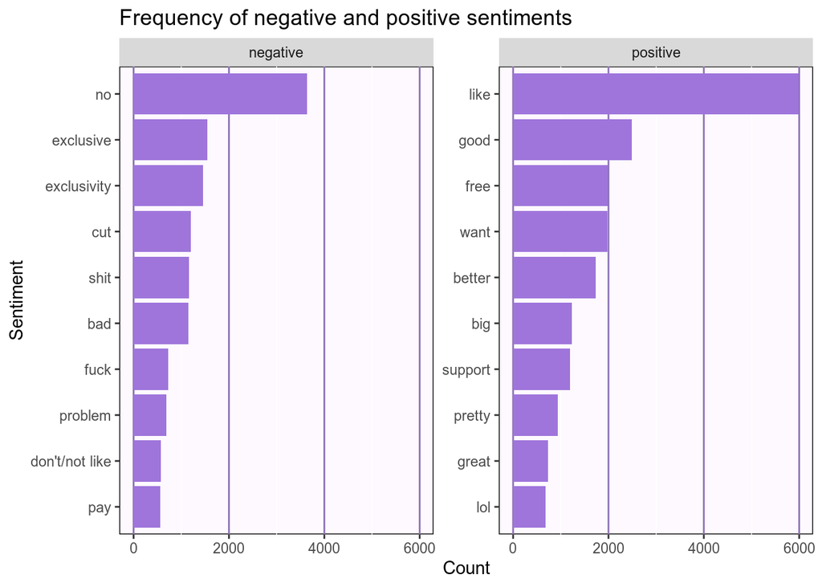

```r
# Frequency bars for positive and negative sentiments
rst_frequency_negpos <- rst_tkn_word_afinn %>%
  count(Sentiment, Word) %>%
  # Modify the "negative like" so there's no problems with factor ordering
  mutate(Word = case_when(Sentiment == 'negative' & Word == 'like' ~ "don't/not like",
                          TRUE ~ Word)) %>%
  group_by(Sentiment) %>%
  top_n(10, n) %>%
  arrange(desc(n), .by_group = TRUE)

rst_frequency_negpos %>%
  ggplot(aes(x = fct_reorder(Word, n), y = n)) +
  geom_bar(stat = "identity", fill = rst_palette[4]) +
  labs(y = "Count",
       x = "Sentiment",
       title = "Frequency of negative and positive sentiments") +
  facet_wrap(~ Sentiment, scale = "free_y") +
  coord_flip()
```

```r
rst_tkn_word_afinn %>%
  count(Sentiment, pre_Word, Word) %>%
  mutate(whole_Word = paste(pre_Word, Word)) %>%
  group_by(Sentiment) %>%
  top_n(10, n) %>%
  arrange(desc(n), .by_group = TRUE)
```

```
## # A tibble: 20 × 5
## # Groups:   Sentiment [2]
##    Sentiment pre_Word Word        n whole_Word
##    <chr>     <chr>    <chr>   <int> <chr>
##  1 negative  have     no        396 have no
##  2 negative  don't    want      298 don't want
##  3 negative  don't    care      281 don't care
##  4 negative  don't    like      281 don't like
##  5 negative  to       pay       240 to pay
##  6 negative  there's  no        237 there's no
##  7 negative  not      like      225 not like
##  8 negative  is       no        220 is no
##  9 negative  the      problem   220 the problem
## 10 negative  a        problem   202 a problem
## 11 positive  a        good      644 a good
## 12 positive  i        want      407 i want
## 13 positive  a        big       396 a big
## 14 positive  they     want      374 they want
## 15 positive  the      best      373 the best
## 16 positive  you      want      372 you want
## 17 positive  the      free      332 the free
## 18 positive  a        better    301 a better
## 19 positive  seems    like      299 seems like
## 20 positive  i        hope      275 i hope
```

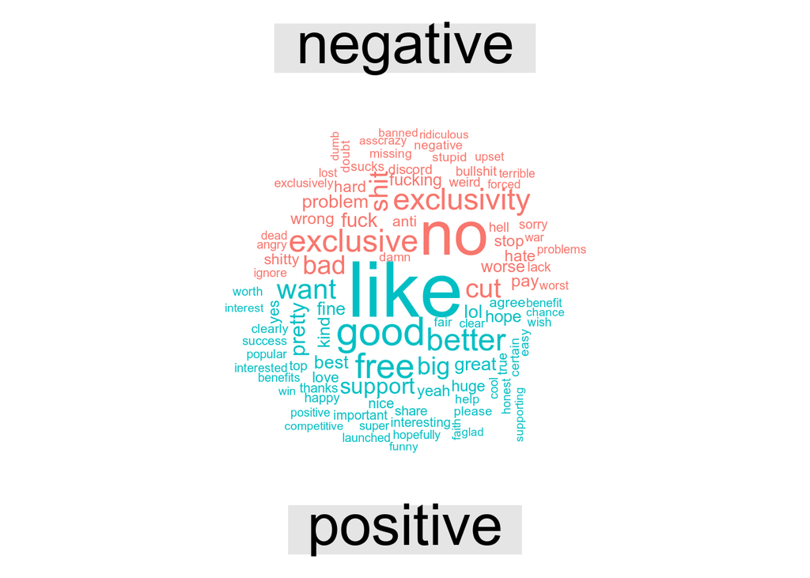

```r
# Wordcloud of positive and negative sentiments
rst_tkn_word_afinn %>%
  count(Word, Sentiment, sort = TRUE) %>%
  acast(Word ~ Sentiment, value.var = "n", fill = 0) %>%
  comparison.cloud(colors = c("#F8766D", "#00BFC4"),
                   max.words = 100)
```

On the positive words, “like” is the most common one, but this has to be treated with caution because “like” is also used as a preposition. In the third place we have “free”, which probably has something to do with the store’s policy of giving away free games each week. On the negative words, “exclusive” and “exclusivity” are in the second and third place, respectively, and in 4th place we have “cut”, which probably is not a negative word in this context because it generally refers to the 11% cut of sales that the store retrieves from game developers, which by industry standards is significantly low (against the 30% from the Steam store, for instance).

Having applied sentiment scores for each word, we can have an aggregate score for each post, and then classifying them as positive or negative, which will be useful to summarize the general feeling towards the store:

```r
# Aggregate scores per post into a new variable called "Post_Value"
rst_tkn_word_afinn <-rst_tkn_word_afinn %>%
  group_by(Post) %>%
  mutate(Post_Value = sum(Value)) %>%
  ungroup()

# Checking the distribution of the scored posts
summary(rst_tkn_word_afinn$Post_Value)
```

```
##    Min. 1st Qu.  Median    Mean 3rd Qu.    Max.
## -50.000  -4.000   0.000   1.007   4.000 183.000
```

```r
sd(rst_tkn_word_afinn$Post_Value)
```

```
## [1] 12.94278
```

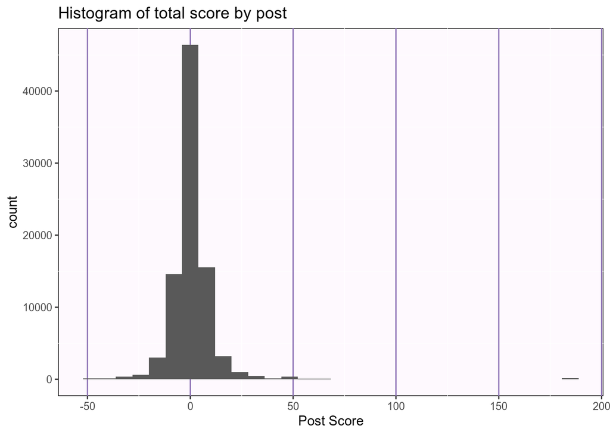

```r
rst_tkn_word_afinn %>%
  ggplot(aes(x = Post_Value)) +
  geom_histogram() +
  labs(title = "Histogram of total score by post",
       x = "Post Score")
```

```r
# Identifying the outlier post and saving it
outlier_post <- (rst_tkn_word_afinn %>% filter(Post_Value == max(.$Post_Value)) %>% pull(Post))[1]

# Let's classify posts according to its total score
rst_tkn_word_afinn <- rst_tkn_word_afinn %>%
  mutate(Post_Sentiment = ifelse(Post_Value > 0, "positive", "negative"))
```

Which are the top 10 threads with positive and negative words?

```r
# Top 10 threads by sentiment
## Positive
rst_tkn_word_afinn %>%
  group_by(Thread_title) %>%
  summarise(Total_value = sum(Value)) %>%
  arrange(desc(Total_value)) %>%
  head(10) %>%
  kable(format = "html", col.names = c("Thread Title", "Total Value")) %>%
  kable_styling(html_font = "Arial Narrow") %>%
  add_header_above(header = c("Top 10 Positive Threads By Total Word Value" = 2), font_size = 20, bold = TRUE)
```

| Top 10 Positive Threads By Total Word Value Thread Title | Top 10 Positive Threads By Total Word Value Total Value |
| --- | --- |
| Epic Games announces multiplatform publishing partnerships with studios behind Control, Limbo, and The Last Guardian | 1434 |
| The Epic Games Store as described by Sergey Galyonkin (SteamSpy Creator, Currently At Epic) (Update: Sergey Clarifying Points on Twitter) | 1367 |
| Epic Games Store Discussion | 952 |
| Rumor: Epic Games Store to Giveaway 14 Games This Month (Up: TOMB RAIDER TRILOGY FREE THRU JAN 6) | 799 |
| Grand Theft Auto V Premium Edition is now free on the Epic Games Store | 735 |
| [PC Gamer] Epic has sunk $500M into the Epic Games Store, doesn’t expect to make a profit until 2027 | 655 |
| Epic Games Store changes its refund policy to match Steam’s, adds local pricing (on some countries) | 439 |
| Epic Games is acquiring Tonic Games Group, parent company of Mediatonic (Fall Guys dev) | 377 |
| Epic Games has acquired Rocket League developer Psyonix [Up: No Announced Plans to Stop Selling Rocket League on Steam] [Read Staff Post & Threadmark] | 353 |
| I actually don’t hate Epic Game Store | 339 |

```r
## Negative
rst_tkn_word_afinn %>%
  group_by(Thread_title) %>%
  summarise(Total_value = sum(Value)) %>%
  arrange(Total_value) %>%
  head(10) %>%
  kable(format = "html", col.names = c("Thread Title", "Total Value")) %>%
  kable_styling(html_font = "Arial Narrow") %>%
  add_header_above(header = c("Top 10 Negative Threads By Total Word Value" = 2), font_size = 20, bold = TRUE)
```

| Top 10 Negative Threads By Total Word Value Thread Title | Top 10 Negative Threads By Total Word Value Total Value |
| --- | --- |
| We need to talk about how toxic discussing the Epic Games Store is when it comes to accusations and insults (Read OP and Threadmarks Before Posting) | -2462 |
| Ooblets will be exclusive to Epic Games Store on PC | -1641 |
| Metro Exodus for PC a timed exclusive for the Epic store (Steam preorders honoured, physical copy with Epic key). [READ staff post] | -1144 |
| Epic Games immediately fucks up Fortnite LGBTQIA+ event by disabling then reinstating homophobe’s financial support | -690 |
| The Outer Worlds, Control, Dauntless, SpellBreak, The Cycle, Ancestors & More Coming As Timed Exclusives To Epic Games Store; TOW also on MS Store | -546 |
| Epic Games Store Exclusive “Tetris Effect” Requires SteamVR to run in VR mode | -518 |
| Kotaku: Epic Games Store will block your account from making purchases if you buy too many games too quickly | -301 |
| [Gematsu] Salt and Sacrifice for PC is launching exclusively on the Epic Games Store | -63 |
| Outer Wilds confirmed EpicStore timed exclusive after luring crowdfundees with a steamrelease. [see EGS guidelines] | -42 |
| Seriously, what’s with the deep and vehement hatred for the Epic Games Store? | -40 |

Among the top positive threads, common themes are giveaways of well known games, such as the Tomb Raider trilogy and Grand Theft Auto V, and the acquisition and partnership with various games developers, such as Remedy Entertainment or Mediatonic. For the top negative threads, the most negative one is about tackling the issue of toxicity around discussions related to the EGS, while other negative threads are about exclusivity of certain games, the mistreatment of a social issue through the company’s own actions ("Epic Games immediately f*cks up…“) and the lack of good services from the store itself (”Kotaku: Epic Games Store will block your account…").

We can also check the top 10 threads not by total word score, but by positive ratios (that is, percentage of positive posts inside each thread):

```r
rst_post_thread_prop <- rst_tkn_word_afinn %>%
  group_by(Thread_title) %>%
  count(Post_Sentiment) %>%
  mutate(Total_n = sum(n),
         Positive_proportion = n / Total_n) %>%
  ungroup()

# Top 10 positive threads by ratio of positives
rst_post_thread_prop %>%
  filter(Post_Sentiment == "positive") %>%
  select(-Post_Sentiment, -n) %>%
  arrange(desc(Positive_proportion)) %>%
  head(10) %>%
  mutate(Positive_proportion = scales::percent(Positive_proportion, 0.01)) %>%
  kable(format = "html", digits = 3, col.names = c("Thread Title", "Nº of Posts", "Positive Ratio (%)")) %>%
  kable_styling(html_font = "Arial Narrow")%>%
  add_header_above(header = c("Top 10 Of Most Positive Threads" = 3), font_size = 20, bold = TRUE)
```

| Top 10 Of Most Positive Threads Thread Title | Top 10 Of Most Positive Threads Nº of Posts | Top 10 Of Most Positive Threads Positive Ratio (%) |
| --- | --- | --- |
| Chernobylite, Paradise Lost, Of Bird and Cage, Alaloth and Fort Triumph coming to the Epic Games Store | 17 | 100.00% |
| GOG Galaxy adds official Epic Games Store integration | 23 | 100.00% |
| Oddworld: New ‘n’ Tasty is Free on the Epic Games Store | 11 | 100.00% |
| Industries of Titan - Early Access Launch (Epic Games Store) | 21 | 95.24% |
| Epic acquires Rad Game Tools (Bink Video, etc) | 125 | 88.00% |
| Wishlist for the Epic Games Store | 20 | 85.00% |
| is the Epic Game Store an always online storefront? | 12 | 83.33% |
| Sony and Epic Games announce deep partnership in new video | 34 | 82.35% |
| Epic Games startes Self-Publishing Closed Beta for Epic Games Store | 101 | 82.18% |
| GOG will start selling Epic Games Store games from Galaxy client | 56 | 80.36% |

```r
# Top 10 negative threads by ratio of positives
rst_post_thread_prop %>%
  filter(Post_Sentiment == "positive") %>%
  select(-Post_Sentiment, -n) %>%
  arrange(Positive_proportion) %>%
  head(10) %>%
  mutate(Positive_proportion = scales::percent(Positive_proportion, 0.01)) %>%
  kable(format = "html", digits = 3, col.names = c("Thread Title", "Nº of Posts", "Positive Ratio (%)")) %>%
  kable_styling(html_font = "Arial Narrow") %>%
  add_header_above(header = c("Top 10 Of Most Negative Threads" = 3), font_size = 20, bold = TRUE)
```

| Top 10 Of Most Negative Threads Thread Title | Top 10 Of Most Negative Threads Nº of Posts | Top 10 Of Most Negative Threads Positive Ratio (%) |
| --- | --- | --- |
| Lets discuss the awful Epic game store refund policy | 47 | 8.51% |
| Salt and Sacrifice for PC exclusive to Epic Games Store | 8 | 12.50% |
| Will Assassin’s Creed: Valhalla be an Epic Games Store exclusive on PC? | 6 | 16.67% |
| How is the Unreal Engine store so far ahead of the Epic Games store? | 25 | 20.00% |
| Maneater coming to the Epic Games Store | 20 | 20.00% |
| Seriously, what’s with the deep and vehement hatred for the Epic Games Store? | 89 | 20.22% |
| Epic Games immediately fucks up Fortnite LGBTQIA+ event by disabling then reinstating homophobe’s financial support | 852 | 22.89% |
| The Epic Games Store could be draining your laptop battery life | 34 | 29.41% |
| We need to talk about how toxic discussing the Epic Games Store is when it comes to accusations and insults (Read OP and Threadmarks Before Posting) | 6550 | 30.00% |
| Epic Games Store Exclusive “Tetris Effect” Requires SteamVR to run in VR mode | 1552 | 32.02% |

## Analysis by periods of time

How did the public opinion towards the store and Epic Games fare over the years? Let’s check the score evolution by month

```r
# Per month-year
## Total sum of scores
rst_tkn_ym_afinn <- rst_tkn_word_afinn %>%
  group_by(Year, Month) %>%
  summarise(Total_word_sentiment = sum(Value)) %>%
  mutate(year_month = paste0(Year, "-", Month) %>% ym())
```

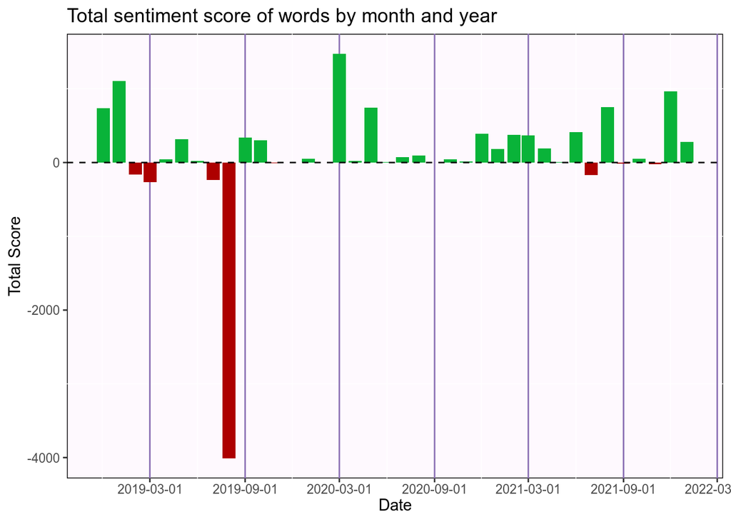

```r
  rst_tkn_ym_afinn %>% ggplot(aes(x = year_month, y = Total_word_sentiment)) +
  geom_bar(stat = "identity", fill = ifelse(rst_tkn_ym_afinn$Total_word_sentiment < 0, "#AD0000", "#09B339")) +
  geom_hline(yintercept = 0, linetype = 2) +
  scale_x_date(date_breaks = "6 months") +
  labs(title = "Total sentiment score of words by month and year",
       x = "Date",
       y = "Total Score") +
  theme(axis.text.x = element_text(angle = 0),
        legend.position = "")
```

```r
rst_tkn_word_afinn %>%
  filter(Year == 2019, Month == 8) %>%
  distinct(Thread_title)
```

```
## # A tibble: 3 × 1
##   Thread_title
##   <chr>
## 1 Oddworld Soulstorm is an Epic Games Store exclusive on PC
## 2 Ooblets will be exclusive to Epic Games Store on PC
## 3 We need to talk about how toxic discussing the Epic Games Store is when it co…
```

We find three identified threads. Two of those have to do with exclusivity deals. Although any exclusivity announced for the store wasn’t met with much appraisal, the Ooblets case was controversial because the developer defended somewhat informally the decision of accepting the offer Epic made to them. This didn’t bode well between the Resetera members, hence, the significant increase in negativity. It really got worse than a few simple unhappy comments, though. Finally, the remaining thread (“We need to talk about…”), which already topped the previous Top 10 negative threads by word score that we’ve shown, was an honest discussion on how debating about the EGS in the forums led to toxic behavior.

What is the total proportion of positive and negative posts in every combination of year and month? For this, we’ll be making a diagram plot with scaled proportions (the scaling is meant to better show which periods were mostly positive or negative):

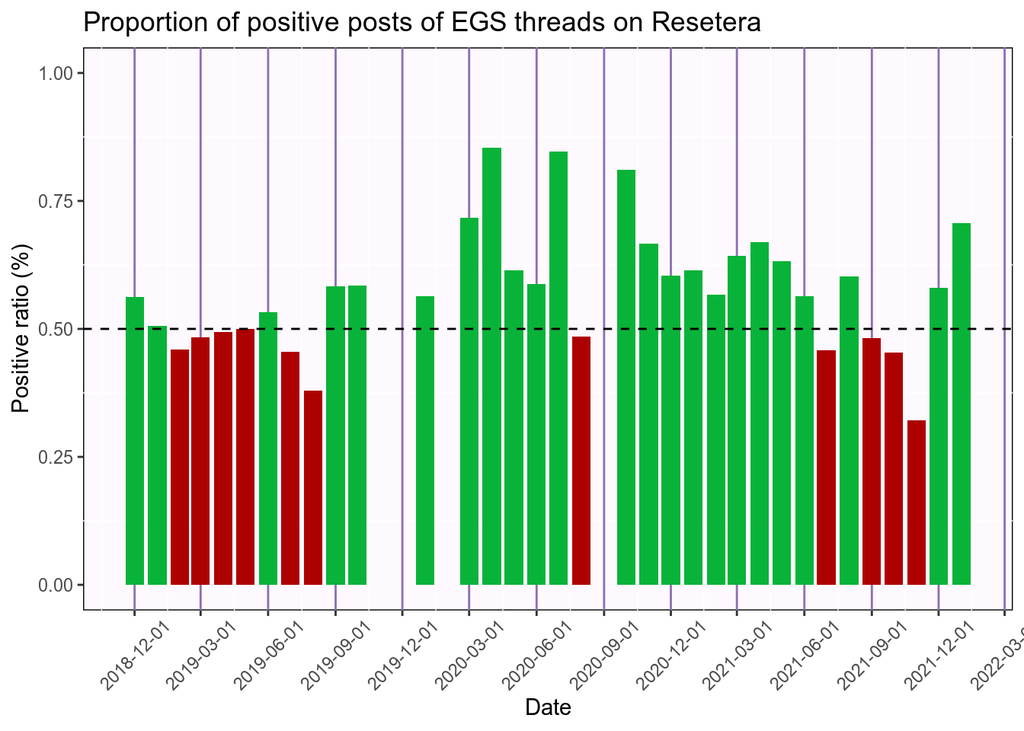

```r
## Calculate proportions by post
rst_post_proportion <- rst_tkn_word_afinn %>%
  group_by(Year, Month) %>%
  count(Post_Sentiment) %>%
  mutate(Proportion = n / sum(n)) %>%
  ungroup() %>%
  mutate(year_month = paste0(Year, "-", Month) %>% ym())

# Which threads belong to the negative periods?
negative_periods <- rst_post_proportion %>%
  filter(Post_Sentiment == "positive", Proportion < 0.5) %>%
  pull(year_month)

# Visualize in a time series
## Without scaling
rst_post_proportion %>%
  filter(Post_Sentiment == "positive") %>%
  ggplot(aes(x = year_month, y = Proportion)) +
  geom_bar(stat = "identity",
           fill = ifelse(filter(rst_post_proportion,
                                Post_Sentiment == "positive")$Proportion < 0.5,  "#AD0000", "#09B339")) +
  geom_hline(yintercept = 0.5, linetype = 2) +
  labs(y = "Positive ratio (%)",
       x = "Date",
       title = "Proportion of positive posts of EGS threads on Resetera") +
  coord_cartesian(ylim = c(0, 1)) +
  scale_x_date(date_breaks = "3 months") +
  theme(panel.grid.minor.y = element_line(),
        axis.text.x = element_text(angle = 45))
```

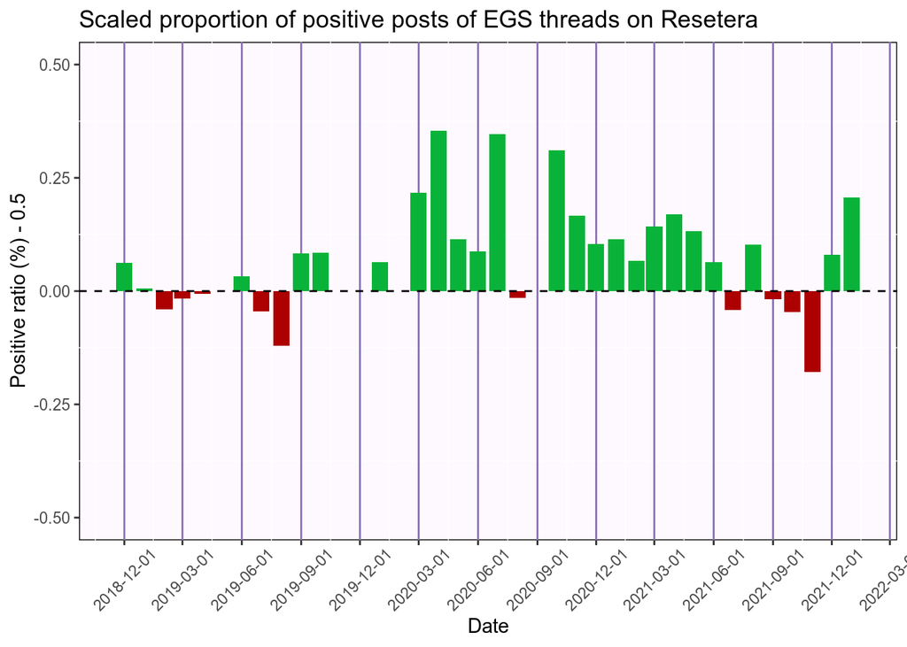

```r
## With scaling
rst_post_proportion %>%
  filter(Post_Sentiment == "positive") %>%
  ggplot(aes(x = year_month, y = Proportion - 0.5)) +
  geom_bar(stat = "identity",
           fill = ifelse(filter(rst_post_proportion,
                                Post_Sentiment == "positive")$Proportion < 0.5,  "#AD0000", "#09B339")) +
  geom_hline(yintercept = 0, linetype = 2) +
  labs(y = "Positive ratio (%) - 0.5",
       x = "Date",
       title = "Scaled proportion of positive posts of EGS threads on Resetera") +
  coord_cartesian(ylim = c(-0.5, 0.5)) +
  scale_x_date(date_breaks = "3 months") +
  theme(panel.grid.minor.y = element_line(),
        axis.text.x = element_text(angle = 45))
```

```r
# Threads from November of 2020 and 2021
rst_tkn_word_afinn %>%
  filter(Month == 11, Year == 2021) %>%
  distinct(Thread_title)
```

```
## # A tibble: 1 × 1
##   Thread_title
##   <chr>
## 1 Riot Games coming to Epic Store
```

Users from the *“Riot Games coming to Epic Store”* thread we’re not that much impressed because both Epic Games and Riot Games are both owned in part from Tencent, another powerful video game company that is not well liked among members on Resetera (Tencent is chinese and Resetera is american, which may explain part of the dislike).

# Conclusions

In this article we’ve shown the use of web scraping and data sciences techniques for gauging the general sentiment about the Epic Games Store in general and over time. Being out for at least four years, we’ve seen here that opinions around the store were mostly negative in the first six months, while in the following years the opinion was somewhat positive with exceptions here and there. Negative scores came from opinions that commented about the exclusivity deals, lack of important features and the ill-treatment of some social issues. On the other hand, positive scores mostly came from opinions about the weekly delivery of free games and some announced partnership deals with well-known videogame companies such as Playdead and Mediatonic. Main issues that arose during the analysis were the mis-classification of words because of unproper account of context, which is difficult to deal with using the current tools. While the AFINN lexicon was useful to some degree, it is intended to analyze Twitter messages, which tend to be much more shorter than forum messages. Therefore, further analysis of sentiments about this topic could benefit from a lexicon designed for forum discussions.

# References

- Finn Årup Nielsen A new ANEW: Evaluation of a word list for sentiment analysis in microblogs. Proceedings of the ESWC2011 Workshop on ‘Making Sense of Microposts’: Big things come in small packages 718 in CEUR Workshop Proceedings 93-98. 2011 May. http://arxiv.org/abs/1103.2903.
- Zhang, Z. (2018). Text Mining for Social and Behavioral Research Using R: A Case Study on Teaching Evaluation. Retrievable from https://books.psychstat.org/textmining.